# Part 2 : FLASH FLOOD SUSCEPTIBILITY USING MACHINE LEARNING

#### By : EL Mehdi SELLAMI

```python
import numpy as np
import pandas as pd
from PIL import Image
import matplotlib.pyplot as plt
from sklearn.model_selection import train_test_split
import seaborn as sns
```

### The raster data underwent a transformation into numerical format using the Sample function within the Spatial Analyst toolset in ArcGIS.

```python
#Dataset of flood points
flood_pts_b=pd.read_csv(r"S:\STUDY\Master SIGGT\PFE\DATA\Machine_learning_dataset\FLOOD.csv",sep=',')
flood_pts_b=flood_pts_b[flood_pts_b.columns[1:]]  #slicing
flood_pts_b["flood"]=1

#Dataset of no flood points
no_flood_pts_b=pd.read_csv(r"S:\STUDY\Master SIGGT\PFE\DATA\Machine_learning_dataset\NO_FLOOD.csv",sep=',')
no_flood_pts_b=no_flood_pts_b[no_flood_pts_b.columns[1:]]  #slicing
no_flood_pts_b["flood"]=0

dataset_b=pd.concat([flood_pts_b,no_flood_pts_b])

dataset_b
```

|  | X | Y | TPI | SPI | LULC | ASPECT | PLAN_CURV | PROFILE_CURV | TWI | SLOPE | ELEVATION | flood |
| --- | --- | --- | --- | --- | --- | --- | --- | --- | --- | --- | --- | --- |
| 0 | 507125.3937 | 556546.3177 | -0.004455 | 3.688700 | 2 | 64.509842 | -0.010412 | 0.006968 | 10.344561 | 0.208311 | -0.033634 | 1 |
| 1 | 507139.6441 | 556439.4397 | 0.000000 | 0.000000 | 2 | -1.000000 | -0.247379 | 0.014036 | 9.295779 | 0.000000 | -0.069131 | 1 |
| 2 | 507328.4619 | 556361.0625 | 0.001517 | 0.000000 | 2 | 163.564880 | 0.005661 | -0.011287 | 9.642947 | 0.013361 | 0.999254 | 1 |
| 3 | 507349.8375 | 556403.8137 | 0.393694 | 0.000000 | 2 | 51.695644 | 0.661829 | -0.578158 | 6.724761 | 0.687979 | 1.858622 | 1 |
| 4 | 507139.6441 | 556325.4365 | -0.008560 | 1.289720 | 2 | 315.000000 | -0.059017 | -0.078887 | 7.349828 | 0.069362 | -0.069131 | 1 |
| ... | ... | ... | ... | ... | ... | ... | ... | ... | ... | ... | ... | ... |
| 844 | 500185.2282 | 548728.2863 | 0.511536 | 5.552193 | 3 | 321.655304 | 0.729638 | -0.402564 | 4.328790 | 14.770994 | 337.489624 | 0 |
| 845 | 500875.2282 | 548708.2863 | 0.788574 | 7.640168 | 2 | 97.174446 | -0.322730 | -1.750953 | 3.873995 | 39.726871 | 420.045136 | 0 |
| 846 | 500885.2282 | 548708.2863 | -1.528534 | 7.873821 | 1 | 95.780243 | -0.316987 | 3.755615 | 4.171902 | 37.637447 | 410.584137 | 0 |
| 847 | 500875.2282 | 548578.2863 | 3.511627 | 0.000000 | 3 | 86.423058 | 5.927244 | -7.139071 | 2.183419 | 48.405830 | 424.183441 | 0 |
| 848 | 500895.2282 | 548378.2863 | 3.929230 | 0.000000 | 3 | 62.444218 | 5.547601 | -8.264167 | 2.709067 | 33.663204 | 425.775147 | 0 |

2024 rows × 12 columns

```python
a=len(no_flood_pts_b)
b=len(flood_pts_b)
c=len(dataset_b)
print('no flood : ',a  ,'flood:',b  ,'total' ,c)
```

```
no flood :  849 flood: 1175 total 2024
```

### Despite some outliers being displayed in the boxplots, they are not considered significant outliers as they accurately represent the reality of the data distribution and are not substantially distant from the overall data distribution

[figure not shown]

```python
dataset_b_=dataset_b[dataset_b.columns[:-1]]
column_names = dataset_b_.columns.tolist()  # List of column names
plt.figure(figsize=(12, 15))

for i, col in enumerate(column_names):
    # Create a subplot for both scatter and box plot
    plt.subplot(3, 3, i + 1)
    plt.boxplot(dataset_b[col])  # Optional: show mean values
    plt.xlabel(col)
    plt.ylabel("")  # Adjust label if needed (e.g., "Price")
plt.tight_layout()

# Display the plot
plt.show()
```

[figure not shown]

```python
dataset_b_=dataset_b[dataset_b.columns[:-1]]
column_names = dataset_b_.columns.tolist()  # List of column names
plt.figure(figsize=(12, 15))  # Adjust figsize for better readability
for i, col in enumerate(column_names):
    plt.subplot(3, 3, i + 1)
    sns.distplot(dataset_b[col])
    plt.title(f"{col} - Distribution")
    plt.xlabel(col)
    plt.ylabel("Frequency")
plt.tight_layout()
plt.show()
```

# xxxxxxxxxxxxx PREPROCESSING xxxxxxxxxxxxxxxxxxx

# Removing Outliers

```python
#IQR method for outliers removels we can't use it in our case .
#In our cas there's no outliers
def remove_ouliers(a):
    print(f"size of dataset before removing outliers : {dataset_b.shape}")
    print(dataset_b[a].describe())
    # Scatter plot (before removing outliers)
    plt.figure(figsize=(12, 6))
    plt.subplot(1, 2, 1)
    sns.distplot(dataset_b[a])
    plt.title(f"Before {a} - distplot ")

    # Boxplot (before removing outliers)
    plt.subplot(1, 2, 2)
    plt.boxplot([dataset_b[a]], labels=["Before"])
    plt.title(f"Before {a} - Box Plot")


    # Calculate IQR and identify outliers
    q25, q75 = np.percentile(a=dataset_b[a], q=[25, 75])
    IQR = q75 - q25
    lower_limit = q25 - 1.5 * IQR
    upper_limit = q75 + 1.5 * IQR


    dataset_b.drop(dataset_b[dataset_b[a] > upper_limit].index, inplace=True)
    dataset_b.drop(dataset_b[dataset_b[a] < lower_limit].index, inplace=True)

    print(lower_limit)
    print(upper_limit)
    # Scatter plot (after removing outliers)
    plt.figure(figsize=(12, 6))
    plt.subplot(1, 2, 1)
    sns.distplot(dataset_b[a])
    plt.title(f"After {a} - distplot ")

    # Boxplot (after removing outliers)
    plt.subplot(1, 2, 2)
    plt.boxplot([dataset_b[a]], labels=["After"])
    plt.title(f"After {a} - Box Plot")
    print(f"size of dataset after removing outliers : {dataset_b.shape}")
    plt.show()
```

```python
import pandas as pd

# Create a dataframe
df = pd.DataFrame({
    "LULC": dataset_b['LULC'],
    "ASPECT": dataset_b['ASPECT'],
    "TWI": dataset_b['TWI'],
    "TPI": dataset_b['TPI'],
    "SLOPE": dataset_b['SLOPE'],
    "PLAN_CURV": dataset_b['PLAN_CURV'],
    "PROFILE_CURV": dataset_b['PROFILE_CURV'],
    "SPI": dataset_b['SPI'],
    "ELEVATION": dataset_b['ELEVATION'],
    "FLOOD": dataset_b["flood"]
})

# Calculate the correlation between each independent variable and the dependent variable
correlation_matrix = df.corr()["FLOOD"]

# Print the correlations
print(correlation_matrix)
```

```
LULC           -0.064057
ASPECT         -0.017425
TWI             0.333786
TPI            -0.142760
SLOPE          -0.213679
PLAN_CURV      -0.149405
PROFILE_CURV    0.079081
SPI             0.140803
ELEVATION      -0.274581
FLOOD           1.000000
Name: FLOOD, dtype: float64
```

[figure not shown]

```
(-0.8393013629495882, 1.0)
1.0
-0.8393013629495882
```

```python
import numpy as np
import matplotlib.pyplot as plt

# Create a correlation matrix
correlation_matrix = df.corr()

# Plot the pairwise correlation matrix
correlation_array = correlation_matrix.values
correlation_matrix
plt.figure(figsize=(10, 10))
plt.imshow(correlation_array, cmap='coolwarm')
plt.colorbar()
plt.xticks(range(len(correlation_matrix)), correlation_matrix.columns)
plt.yticks(range(len(correlation_matrix)), correlation_matrix.columns)
plt.title('Pairwise Correlation Matrix')

# Add text to the heatmap
for i in range(len(correlation_array)):
    for j in range(len(correlation_array[0])):
        plt.text(j, i, f"{correlation_array[i][j]:.2f}", ha="center", va="center", color="black")

plt.show()


# Get the correlation coefficients range, max value and min value
correlation_range = np.min(correlation_matrix.values), np.max(correlation_matrix.values)
correlation_max = np.max(correlation_matrix.values)
correlation_min = np.min(correlation_matrix.values)

# Print the results
print(correlation_range)
print(correlation_max)
print(correlation_min)
```

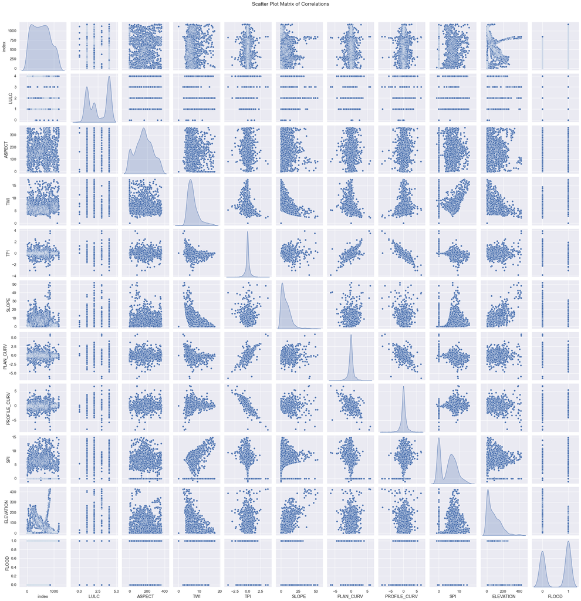

```python
import pandas as pd
import seaborn as sns
import matplotlib.pyplot as plt

# Remove the duplicate values from the DataFrame
df = df.drop_duplicates()
df = df.reset_index()

# Calculate the pairwise correlation matrix
correlation_matrix = df.corr()

# Create a scatter plot matrix of the correlations
plt.figure(figsize=(10, 8))
sns.set(font_scale=1.2)
sns.pairplot(data=df, kind='scatter', diag_kind='kde')
plt.suptitle('Scatter Plot Matrix of Correlations', y=1.02)
plt.show()
```

```python
print(dataset_b["flood"].describe())
print(dataset_b["flood"].unique())
```

```
count    2024.000000
mean        0.580534
std         0.493594
min         0.000000
25%         0.000000
50%         1.000000
75%         1.000000
max         1.000000
Name: flood, dtype: float64
[1 0]
```

```python
dataset_b
```

|  | X | Y | TPI | SPI | LULC | ASPECT | PLAN_CURV | PROFILE_CURV | TWI | SLOPE | ELEVATION | flood |
| --- | --- | --- | --- | --- | --- | --- | --- | --- | --- | --- | --- | --- |
| 0 | 507125.3937 | 556546.3177 | -0.004455 | 3.688700 | 2 | 64.509842 | -0.010412 | 0.006968 | 10.344561 | 0.208311 | -0.033634 | 1 |
| 1 | 507139.6441 | 556439.4397 | 0.000000 | 0.000000 | 2 | -1.000000 | -0.247379 | 0.014036 | 9.295779 | 0.000000 | -0.069131 | 1 |
| 2 | 507328.4619 | 556361.0625 | 0.001517 | 0.000000 | 2 | 163.564880 | 0.005661 | -0.011287 | 9.642947 | 0.013361 | 0.999254 | 1 |
| 3 | 507349.8375 | 556403.8137 | 0.393694 | 0.000000 | 2 | 51.695644 | 0.661829 | -0.578158 | 6.724761 | 0.687979 | 1.858622 | 1 |
| 4 | 507139.6441 | 556325.4365 | -0.008560 | 1.289720 | 2 | 315.000000 | -0.059017 | -0.078887 | 7.349828 | 0.069362 | -0.069131 | 1 |
| ... | ... | ... | ... | ... | ... | ... | ... | ... | ... | ... | ... | ... |
| 844 | 500185.2282 | 548728.2863 | 0.511536 | 5.552193 | 3 | 321.655304 | 0.729638 | -0.402564 | 4.328790 | 14.770994 | 337.489624 | 0 |
| 845 | 500875.2282 | 548708.2863 | 0.788574 | 7.640168 | 2 | 97.174446 | -0.322730 | -1.750953 | 3.873995 | 39.726871 | 420.045136 | 0 |
| 846 | 500885.2282 | 548708.2863 | -1.528534 | 7.873821 | 1 | 95.780243 | -0.316987 | 3.755615 | 4.171902 | 37.637447 | 410.584137 | 0 |
| 847 | 500875.2282 | 548578.2863 | 3.511627 | 0.000000 | 3 | 86.423058 | 5.927244 | -7.139071 | 2.183419 | 48.405830 | 424.183441 | 0 |
| 848 | 500895.2282 | 548378.2863 | 3.929230 | 0.000000 | 3 | 62.444218 | 5.547601 | -8.264167 | 2.709067 | 33.663204 | 425.775147 | 0 |

2024 rows × 12 columns

# xxxxxxxxxxxxx TRAINING xxxxxxxxxxxxxxxxxxx

```python
from sklearn.preprocessing import StandardScaler

features_b_=(dataset_b[dataset_b.columns[:-1]])
category_b=np.array((dataset_b[dataset_b.columns[-1:]])).ravel()


scaler = StandardScaler()
features_b= scaler.fit_transform(features_b_)

#70% Train  Data , 30% Test Data
#I must add random-state ☺ random_state=0
```

```python
features_b_.columns
```

```
Index(['X', 'Y', 'TPI', 'SPI', 'LULC', 'ASPECT', 'PLAN_CURV', 'PROFILE_CURV',
       'TWI', 'SLOPE', 'ELEVATION'],
      dtype='object')
```

```python
from sklearn.model_selection import KFold, StratifiedKFold, cross_val_score

kf = StratifiedKFold(n_splits=4, shuffle=True, random_state=42)


cnt = 1
# split()  method generate indices to split data into training and test set.
for train_index, test_index in kf.split(features_b, category_b):
    print(f'Fold:{cnt}, Train set: {len(train_index)}, Test set:{len(test_index)}')
    cnt+=1
```

```
Fold:1, Train set: 1518, Test set:506
Fold:2, Train set: 1518, Test set:506
Fold:3, Train set: 1518, Test set:506
Fold:4, Train set: 1518, Test set:506
```

```python
area=pd.read_csv(r"S:\STUDY\Master SIGGT\PFE\DATA\Machine_learning_dataset\DATASET.csv",sep=',') #Data contanis our study area
area=area[area.columns[1:]]  #slicing
area
```

|  | X | Y | TPI | SPI | LULC | ASPECT | PLAN_CURV | PROFILE_CURV | TWI | SLOPE | ELEVATION |
| --- | --- | --- | --- | --- | --- | --- | --- | --- | --- | --- | --- |
| 0 | 505815.2282 | 557748.2863 | 0.0 | 0.000000 | 1 | 230.822220 | -0.094174 | -0.101288 | 7.170336 | 0.440633 | 20.747704 |
| 1 | 505825.2282 | 557748.2863 | 0.0 | 0.000000 | 1 | 204.348846 | 0.097021 | -0.018305 | 8.354400 | 0.134850 | 20.803585 |
| 2 | 505835.2282 | 557748.2863 | 0.0 | 1.444952 | 4 | 355.614197 | -0.077485 | 0.053079 | 10.250294 | 0.081010 | 20.748775 |
| 3 | 505845.2282 | 557748.2863 | 0.0 | 0.000000 | 4 | 211.989471 | 0.069582 | -0.064862 | 8.652495 | 0.100090 | 20.813112 |
| 4 | 505855.2282 | 557748.2863 | 0.0 | 0.000000 | 4 | 86.622063 | -0.022505 | -0.144309 | 7.278141 | 0.395603 | 20.767572 |
| ... | ... | ... | ... | ... | ... | ... | ... | ... | ... | ... | ... |
| 550472 | 501085.2282 | 548038.2863 | 0.0 | 0.000000 | 2 | 294.618713 | 0.979855 | -3.676090 | 4.012162 | 10.256262 | 381.882446 |
| 550473 | 501055.2282 | 548028.2863 | 0.0 | 4.751161 | 2 | 326.607086 | 0.237202 | 0.049336 | 5.147848 | 6.630192 | 376.387970 |
| 550474 | 501065.2282 | 548028.2863 | 0.0 | 0.000000 | 2 | 302.603241 | -1.285954 | 0.209225 | 4.043264 | 9.948556 | 377.344238 |
| 550475 | 501075.2282 | 548028.2863 | 0.0 | 0.000000 | 2 | 291.277618 | 1.188284 | -3.909463 | 3.906459 | 11.371402 | 380.570679 |
| 550476 | 501065.2282 | 548018.2863 | 0.0 | 0.000000 | 1 | 305.607300 | 0.000000 | -1.316376 | 5.046661 | 3.679492 | 378.660614 |

550477 rows × 11 columns

```python
from sklearn.discriminant_analysis import QuadraticDiscriminantAnalysis
from sklearn.ensemble import RandomForestClassifier
from sklearn.svm import SVC,LinearSVR
from sklearn.linear_model import LogisticRegression
from sklearn import linear_model, tree, ensemble
from sklearn.metrics import classification_report
from sklearn.metrics import confusion_matrix
from sklearn.metrics import accuracy_score

from sklearn.model_selection import train_test_split
```

```python
#TUNING SVM
c = [10,14,20,30,50,100]
for val in c:
    score = cross_val_score(SVC(kernel="rbf",C=val,probability=True,random_state= 42), features_b, category_b, cv= kf, scoring="accuracy")
    print(f'Average score({val}): {"{:.3f}".format(score.mean())}')
```

```
Average score(10): 0.862
Average score(14): 0.866
Average score(20): 0.869
Average score(30): 0.864
Average score(50): 0.866
Average score(100): 0.860
```

```python
X_train, X_test, y_train, y_test = train_test_split(features_b, category_b, test_size=0.30)
```

# SVM

```python
model_svm = SVC(kernel="rbf",C=20,probability=True,random_state= 42)
model_svm.fit(X_train, y_train)
predict_svm=model_svm.predict(X_test)
model_svm.score(X_test,y_test)
```

```
0.8618421052631579
```

```
              precision    recall  f1-score   support

           0       0.83      0.80      0.81       232
           1       0.88      0.90      0.89       376

    accuracy                           0.86       608
   macro avg       0.86      0.85      0.85       608
weighted avg       0.86      0.86      0.86       608

kappa: 0.7048270760125763
confusion matrix of SVM :
```

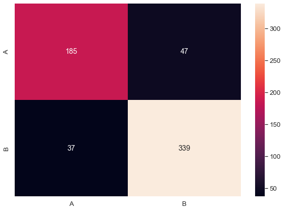

```python
from sklearn.metrics import confusion_matrix
from sklearn.metrics import cohen_kappa_score

import seaborn as sn

print(classification_report(y_test, predict_svm))
print(f"kappa: {cohen_kappa_score(y_test, predict_svm)}" )

a=confusion_matrix(y_test, predict_svm)
print("confusion matrix of SVM :")
df_cm = pd.DataFrame(a, index = [i for i in "AB"],
                  columns = [i for i in "AB"])
plt.figure(figsize = (10,7))
sn.heatmap(df_cm, annot=True,fmt='g')
```

```python
svm=model_svm.predict_proba(scaler.fit_transform(area))
a=svm[:,1:]
area["class"]=a
print(area["class"].describe())
print(area["class"].unique())
```

```
count    5.504770e+05
mean     5.672776e-01
std      3.581385e-01
min      1.343814e-07
25%      2.009635e-01
50%      6.526242e-01
75%      9.185218e-01
max      9.999977e-01
Name: class, dtype: float64
[0.49327338 0.5911302  0.5        ... 0.08960879 0.12711635 0.04579046]
```

```
0.9268674339691857
```

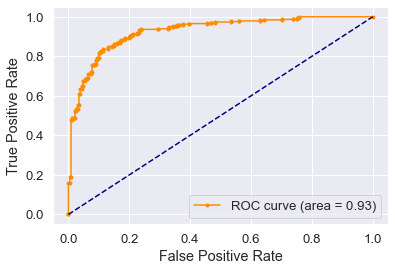

```python
from sklearn.metrics import roc_auc_score
from sklearn.metrics import roc_curve
from matplotlib import pyplot

predict_svm=model_svm.predict_proba(X_test)
predict_svm=predict_svm[:, 1]

lr_auc = roc_auc_score(y_test, predict_svm)
print(lr_auc)
lr_fpr, lr_tpr, _ = roc_curve(y_test, predict_svm)

# plot the roc curve for the model
pyplot.plot(lr_fpr, lr_tpr, marker='.', color='darkorange' , label='ROC curve (area = %0.2f)' % lr_auc)
plt.plot([0, 1], [0, 1], color='navy', linestyle='--')

# axis labels
pyplot.xlabel('False Positive Rate')
pyplot.ylabel('True Positive Rate')
# show the legend
pyplot.legend()
# show the plot
pyplot.show()
```

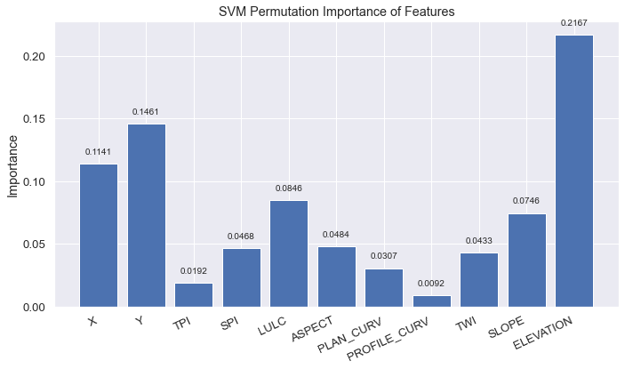

```python
import numpy as np
from sklearn.model_selection import train_test_split
from sklearn.metrics import accuracy_score
from sklearn.inspection import permutation_importance
import matplotlib.pyplot as plt

# Assume you have trained a RandomForestClassifier and assigned it to 'rfc'

# Calculate permutation importances
perm_importance = permutation_importance(model_svm, X_test, y_test, n_repeats=30, random_state=42)

# Get feature importances
feature_importances = perm_importance.importances_mean

# Extract feature names from the DataFrame
feature_names = features_b_.columns

# Optionally, plot the feature importances
plt.figure(figsize=(10, 6))
plt.bar(range(len(features_b_.columns)), feature_importances, tick_label=feature_names)
plt.xlabel('')
plt.ylabel('Importance')
plt.xticks(rotation=25, ha='right')  # Rotate x-axis labels 45 degrees

plt.title('SVM Permutation Importance of Features')

# Annotate the bars with the importance values
for i, v in enumerate(feature_importances):
    plt.text(i, v + 0.006, f'{v:.4f}', ha='center', va='bottom', fontsize=10)

plt.tight_layout()
plt.show()
```

```python
#Just to save our dataset
path_final=r'S:\STUDY\Master SIGGT\PFE\DATA\Machine_learning_dataset\SVM.csv'
area.to_csv(path_final)
```

#### After exporting the data into a CSV format, it will be imported into GIS software and displayed using X and Y coordinates for each pixel. Subsequently, these points are transformed into a raster format for further analysis and visualization.

# Logistic Regression

```python
#tuning LR

algorithms = ['newton-cg', 'lbfgs', 'liblinear', 'sag', 'saga']

for algo in algorithms:
    score = cross_val_score(LogisticRegression(solver= algo, random_state= 42), features_b, category_b, cv= kf, scoring="accuracy")
    print(f'Average score({algo}): {"{:.3f}".format(score.mean())}')
```

```
Average score(newton-cg): 0.688
Average score(lbfgs): 0.688
Average score(liblinear): 0.688
Average score(sag): 0.688
Average score(saga): 0.688
```

```python
from sklearn.linear_model import LogisticRegression

model_LR=LogisticRegression().fit(X_train, y_train)
predict_LR=model_LR.predict(X_test)
predict_LR=model_LR.predict(X_test)
model_LR.score(X_test,y_test)
```

```
0.6858552631578947
```

```
              precision    recall  f1-score   support

           0       0.59      0.57      0.58       232
           1       0.74      0.76      0.75       376

    accuracy                           0.69       608
   macro avg       0.67      0.66      0.67       608
weighted avg       0.68      0.69      0.68       608

kappa: 0.33050456599944655
confusion matrix of LR :
```

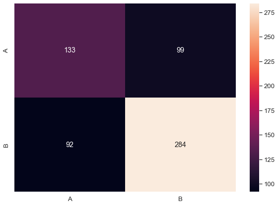

```python
from sklearn.metrics import confusion_matrix
from sklearn.metrics import cohen_kappa_score

import seaborn as sn

print(classification_report(y_test, predict_LR))
print(f"kappa: {cohen_kappa_score(y_test, predict_LR)}" )

a=confusion_matrix(y_test, predict_LR)
print("confusion matrix of LR :")
df_cm = pd.DataFrame(a, index = [i for i in "AB"],
                  columns = [i for i in "AB"])
plt.figure(figsize = (10,7))
sn.heatmap(df_cm, annot=True,fmt='g')
```

```python
area=pd.read_csv(r"S:\STUDY\Master SIGGT\PFE\DATA\Machine_learning_dataset\DATASET.csv",sep=',') #Data contanis our study area
area=area[area.columns[1:]]  #slicing
area

LR=model_LR.predict_proba(scaler.fit_transform(area))
a=LR[:,1:]
area["class"]=a
print(area["class"].describe())
print(area["class"].unique())
```

```
count    550477.000000
mean          0.570947
std           0.210647
min           0.000058
25%           0.430929
50%           0.578300
75%           0.726460
max           0.999354
Name: class, dtype: float64
[0.83429862 0.88951521 0.94955217 ... 0.01184403 0.01876428 0.01668737]
```

```
0.7356703961848863
```

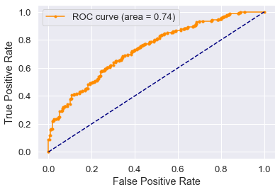

```python
from sklearn.metrics import roc_auc_score
from sklearn.metrics import roc_curve
from matplotlib import pyplot

predict_LR=model_LR.predict_proba(X_test)
predict_LR=predict_LR[:, 1]

lr_auc = roc_auc_score(y_test, predict_LR)
print(lr_auc)
lr_fpr, lr_tpr, _ = roc_curve(y_test, predict_LR)

# plot the roc curve for the model
pyplot.plot(lr_fpr, lr_tpr, marker='.', color='darkorange' , label='ROC curve (area = %0.2f)' % lr_auc)
plt.plot([0, 1], [0, 1], color='navy', linestyle='--')

# axis labels
pyplot.xlabel('False Positive Rate')
pyplot.ylabel('True Positive Rate')
# show the legend
pyplot.legend()
# show the plot
pyplot.show()
```

[figure not shown]

```python
import numpy as np
from sklearn.model_selection import train_test_split
from sklearn.metrics import accuracy_score
from sklearn.inspection import permutation_importance
import matplotlib.pyplot as plt

# Assume you have trained a RandomForestClassifier and assigned it to 'rfc'

# Calculate permutation importances
perm_importance = permutation_importance(model_LR, X_test, y_test, n_repeats=30, random_state=42)

# Get feature importances
feature_importances = perm_importance.importances_mean

# Extract feature names from the DataFrame
feature_names = features_b_.columns

# Optionally, plot the feature importances
plt.figure(figsize=(10, 6))
plt.bar(range(len(features_b_.columns)), feature_importances, tick_label=feature_names)
plt.xlabel('')
plt.ylabel('Permutation Importance')


plt.xticks(rotation=25, ha='right')  # Rotate x-axis labels 45 degrees

plt.title('SVM Permutation Importance of Features')

# Annotate the bars with the importance values
for i, v in enumerate(feature_importances):
    plt.text(i, v + 0.00, f'{v:.4f}', ha='center', va='bottom', fontsize=10)

plt.tight_layout()
plt.show()
```

```python
#Just to save our dataset
path_final=r'S:\STUDY\Master SIGGT\PFE\DATA\Machine_learning_dataset\LR.csv'
area.to_csv(path_final)
```

#### After exporting the data into a CSV format, it will be imported into GIS software and displayed using X and Y coordinates for each pixel. Subsequently, these points are transformed into a raster format for further analysis and visualization.

# Random Forest

```python
#tuning RF


n_estimators = [50, 100, 150, 200, 250, 300, 350]

for val in n_estimators:
    score = cross_val_score(ensemble.RandomForestClassifier(n_estimators= val, random_state= 42), features_b, category_b, cv= kf, scoring="accuracy")
    print(f'Average score({val}): {"{:.3f}".format(score.mean())}')
```

```
Average score(50): 0.910
Average score(100): 0.916
Average score(150): 0.914
Average score(200): 0.915
Average score(250): 0.915
Average score(300): 0.912
Average score(350): 0.913
```

```python
rfc = RandomForestClassifier(n_estimators= 200, random_state= 42)
rfc.fit(X_train, y_train)
predict_rfc=rfc.predict(X_test)
rfc.score(X_test,y_test)
```

```
0.9210526315789473
```

```
              precision    recall  f1-score   support

           0       0.92      0.87      0.89       232
           1       0.92      0.95      0.94       376

    accuracy                           0.92       608
   macro avg       0.92      0.91      0.92       608
weighted avg       0.92      0.92      0.92       608

kappa: 0.8310485364949982
confusion matrix of RF :
```

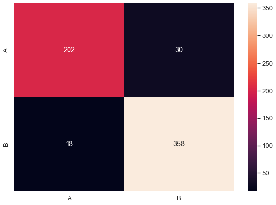

```python
from sklearn.metrics import confusion_matrix
from sklearn.metrics import cohen_kappa_score
import seaborn as sn

print(classification_report(y_test, predict_rfc))
print(f"kappa: {cohen_kappa_score(y_test, predict_rfc)}" )

a=confusion_matrix(y_test, predict_rfc)
print("confusion matrix of RF :")
df_cm = pd.DataFrame(a, index = [i for i in "AB"],
                  columns = [i for i in "AB"])
plt.figure(figsize = (10,7))
sn.heatmap(df_cm, annot=True,fmt='g')
```

```python
area=pd.read_csv(r"S:\STUDY\Master SIGGT\PFE\DATA\Machine_learning_dataset\DATASET.csv",sep=',') #Data contanis our study area
area=area[area.columns[1:]]  #slicing
area


LR=rfc.predict_proba(scaler.fit_transform(area))
a=LR[:,1:]
area["class"]=a
print(area["class"].describe())
print(area["class"].unique())
```

```
count    550477.000000
mean          0.603666
std           0.271119
min           0.000000
25%           0.380000
50%           0.655000
75%           0.850000
max           1.000000
Name: class, dtype: float64
[0.72  0.735 0.68  0.7   0.69  0.76  0.775 0.77  0.725 0.755 0.705 0.635
 0.565 0.585 0.74  0.675 0.605 0.5   0.57  0.595 0.67  0.485 0.56  0.71
 0.4   0.545 0.555 0.625 0.59  0.615 0.415 0.395 0.505 0.33  0.37  0.38
 0.345 0.3   0.41  0.44  0.48  0.45  0.66  0.695 0.495 0.465 0.51  0.49
 0.535 0.47  0.36  0.42  0.35  0.29  0.375 0.475 0.455 0.54  0.55  0.685
 0.82  0.715 0.665 0.525 0.32  0.26  0.425 0.655 0.65  0.52  0.515 0.64
 0.39  0.46  0.645 0.6   0.355 0.305 0.73  0.53  0.435 0.405 0.75  0.58
 0.385 0.79  0.745 0.805 0.765 0.43  0.78  0.785 0.575 0.8   0.62  0.795
 0.815 0.445 0.61  0.63  0.81  0.34  0.27  0.325 0.285 0.365 0.265 0.245
 0.275 0.335 0.295 0.28  0.315 0.31  0.24  0.23  0.25  0.205 0.255 0.235
 0.835 0.85  0.855 0.83  0.22  0.825 0.84  0.21  0.225 0.845 0.2   0.86
 0.87  0.865 0.215 0.175 0.16  0.195 0.19  0.185 0.17  0.155 0.165 0.145
 0.18  0.15  0.88  0.875 0.89  0.9   0.895 0.885 0.905 0.915 0.925 0.91
 0.92  0.935 0.945 0.93  0.95  0.955 0.94  0.96  0.97  0.965 0.975 0.98
 0.985 0.99  0.995 0.135 0.11  0.125 0.12  0.14  0.105 0.13  0.115 0.075
 0.09  0.1   0.07  0.06  0.085 0.095 0.065 0.08  0.045 0.04  0.05  0.03
 0.055 0.035 1.    0.02  0.025 0.015 0.01  0.005 0.   ]
```

```
0.9767516507703595
```

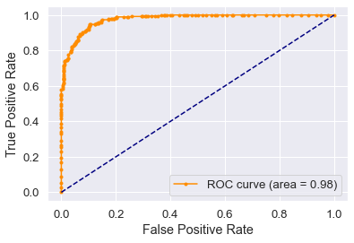

```python
from sklearn.metrics import roc_auc_score
from sklearn.metrics import roc_curve
from matplotlib import pyplot

predict_rfc=rfc.predict_proba(X_test)
predict_rfc=predict_rfc[:, 1]

lr_auc = roc_auc_score(y_test, predict_rfc)
print(lr_auc)
lr_fpr, lr_tpr, _ = roc_curve(y_test, predict_rfc)

# plot the roc curve for the model
pyplot.plot(lr_fpr, lr_tpr, marker='.', color='darkorange' , label='ROC curve (area = %0.2f)' % lr_auc)
plt.plot([0, 1], [0, 1], color='navy', linestyle='--')

# axis labels
pyplot.xlabel('False Positive Rate')
pyplot.ylabel('True Positive Rate')
# show the legend
pyplot.legend()
# show the plot
pyplot.show()
```

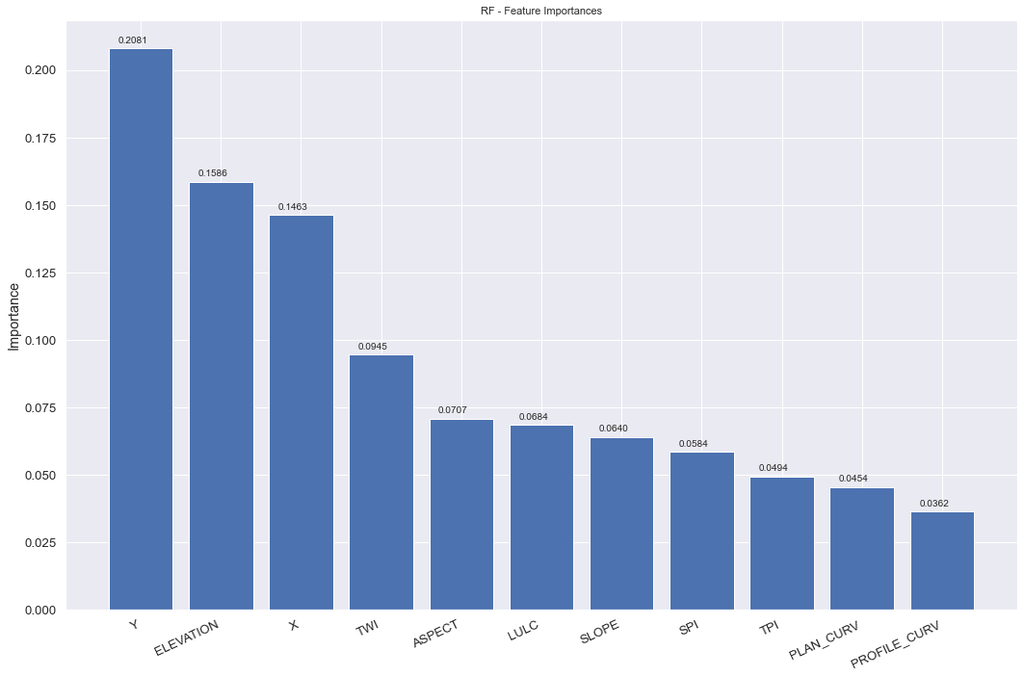

```python
import numpy as np
import pandas as pd
import matplotlib.pyplot as plt
from sklearn.ensemble import RandomForestClassifier


# Replace 'rfc' with your RandomForestClassifier model
# Replace 'X_test' and 'y_test' with your test data
# Ensure 'features_b' contains the feature names

# Calculate feature importances
importances = pd.DataFrame(data={
    'Attribute': dataset_b.columns[:-1],
    'Importance': rfc.feature_importances_
})

# Sort the importances in descending order
importances = importances.sort_values(by='Importance', ascending=False)

# Plot the feature importances with annotations
plt.figure(figsize=(15, 10))
bars = plt.bar(x=importances['Attribute'], height=importances['Importance'])
plt.title('RF - Feature Importances', size=11)

plt.xticks(rotation=25, ha='right')  # Rotate x-axis labels 45 degrees



# Annotate the values on the plot
for bar, importance in zip(bars, importances['Importance']):
    plt.text(bar.get_x() + bar.get_width() / 2 - 0.1, bar.get_height() + 0.002, f'{importance:.4f}', ha='center', fontsize=10)

plt.xlabel('')
plt.ylabel('Importance')
plt.tight_layout()
plt.show()
```

```python
#Just to save our dataset
path_final=r'S:\STUDY\Master SIGGT\PFE\DATA\Machine_learning_dataset\RF.csv'
area.to_csv(path_final)
```

#### After exporting the data into a CSV format, it will be imported into GIS software and displayed using X and Y coordinates for each pixel. Subsequently, these points are transformed into a raster format for further analysis and visualization.

# Multi-Layer Perceptrons (MLPs)

```python
from sklearn.neural_network import MLPClassifier
from sklearn.metrics import classification_report


# Define hyperparameter combinations
hidden_layer_sizes = [(7, 7),(10, 10), (15, 15), (20, 20)]
learning_rate_init = [0.01,0.03,0.05, 0.09, 0.1,0.3]

best_score = 0
best_params = None

for layers in hidden_layer_sizes:
    for rate in learning_rate_init:
        mlp = MLPClassifier(hidden_layer_sizes=layers, learning_rate_init=rate, random_state=0)
        mlp.out_activation_ = 'sigmoid'
        mlp.n_layers_=8
        score = cross_val_score(mlp, features_b, category_b, cv=kf, scoring="accuracy")
        avg_score = score.mean()
        if avg_score > best_score:
            best_score = avg_score
            best_params = {'hidden_layer_sizes': layers, 'learning_rate_init': rate}

print(f"Best score: {best_score:.3f} with params: {best_params}")
```

```
Best score: 0.874 with params: {'hidden_layer_sizes': (15, 15), 'learning_rate_init': 0.01}
```

```python
from sklearn.neural_network import MLPClassifier
from sklearn.metrics import classification_report

mlp = MLPClassifier(hidden_layer_sizes=(15, 15),learning_rate_init=0.01,random_state=0)
mlp.out_activation_ = 'sigmoid'

mlp.n_layers_=8
mlp.fit(X_train, y_train)

print(mlp.score(X_test,y_test))
predict_test_mlp=mlp.predict(X_test)
```

```
0.8782894736842105
```

```
              precision    recall  f1-score   support

           0       0.85      0.83      0.84       232
           1       0.90      0.91      0.90       376

    accuracy                           0.88       608
   macro avg       0.87      0.87      0.87       608
weighted avg       0.88      0.88      0.88       608

kappa: 0.7408294930875576
confusion matrix of RF :
```

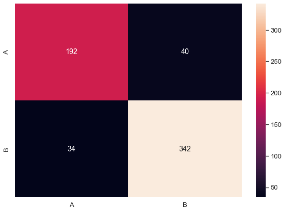

```python
from sklearn.metrics import confusion_matrix
from sklearn.metrics import cohen_kappa_score
import seaborn as sn

print(classification_report(y_test, predict_test_mlp))
print(f"kappa: {cohen_kappa_score(y_test, predict_test_mlp)}" )

a=confusion_matrix(y_test, predict_test_mlp)
print("confusion matrix of RF :")
df_cm = pd.DataFrame(a, index = [i for i in "AB"],
                  columns = [i for i in "AB"])
plt.figure(figsize = (10,7))
sn.heatmap(df_cm, annot=True,fmt='g')
```

```python
area=pd.read_csv(r"S:\STUDY\Master SIGGT\PFE\DATA\Machine_learning_dataset\DATASET.csv",sep=',') #Data contanis our study area
area=area[area.columns[1:]]  #slicing
area


MLP=mlp.predict_proba(scaler.fit_transform(area))
a=MLP[:,1:]
area["class"]=a
print(area["class"].describe())
print(area["class"].unique())
```

```
count    5.504770e+05
mean     5.317292e-01
std      4.070562e-01
min      5.427267e-19
25%      6.462387e-02
50%      6.022274e-01
75%      9.643201e-01
max      1.000000e+00
Name: class, dtype: float64
[6.12730422e-04 3.09092553e-02 2.49460036e-02 ... 7.73349708e-11
 6.86752280e-15 8.47631456e-14]
```

```
0.9461206896551724
```

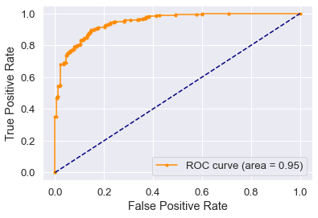

```python
from sklearn.metrics import roc_auc_score
from sklearn.metrics import roc_curve
from matplotlib import pyplot

predict_mlp=mlp.predict_proba(X_test)
predict_mlp=predict_mlp[:, 1]

lr_auc = roc_auc_score(y_test, predict_mlp)
print(lr_auc)
lr_fpr, lr_tpr, _ = roc_curve(y_test, predict_mlp)

# plot the roc curve for the model
pyplot.plot(lr_fpr, lr_tpr, marker='.', color='darkorange' , label='ROC curve (area = %0.2f)' % lr_auc)
plt.plot([0, 1], [0, 1], color='navy', linestyle='--')

# axis labels
pyplot.xlabel('False Positive Rate')
pyplot.ylabel('True Positive Rate')
# show the legend
pyplot.legend()
# show the plot
pyplot.show()
```

[figure not shown]

```python
import numpy as np
from sklearn.model_selection import train_test_split
from sklearn.metrics import accuracy_score
from sklearn.inspection import permutation_importance
import matplotlib.pyplot as plt

# Assume you have trained a RandomForestClassifier and assigned it to 'rfc'

# Calculate permutation importances
perm_importance = permutation_importance(mlp, X_test, y_test, n_repeats=30, random_state=42)

# Get feature importances
feature_importances = perm_importance.importances_mean

# Extract feature names from the DataFrame
feature_names = features_b_.columns

# Optionally, plot the feature importances
plt.figure(figsize=(10, 6))
plt.bar(range(len(features_b_.columns)), feature_importances, tick_label=feature_names)
plt.xlabel('')
plt.ylabel('Permutation Importance')


plt.xticks(rotation=25, ha='right')  # Rotate x-axis labels 45 degrees

plt.title('SVM Permutation Importance of Features')

# Annotate the bars with the importance values
for i, v in enumerate(feature_importances):
    plt.text(i, v + 0.00, f'{v:.4f}', ha='center', va='bottom', fontsize=10)

plt.tight_layout()
plt.show()
```

```python
#Just to save our dataset
path_final=r'S:\STUDY\Master SIGGT\PFE\DATA\Machine_learning_dataset\MLP.csv'
area.to_csv(path_final)
```

# Naive Bayes

```python
from sklearn.naive_bayes import GaussianNB



# Define smoothing values to try
smoothing_values = np.logspace(-9, 0, num=10)

best_score = 0
best_smoothing = None

# Loop through smoothing values
for smoothing in smoothing_values:
    nb = GaussianNB(var_smoothing=smoothing)  # Set smoothing for each iteration
    score = cross_val_score(nb, features_b, category_b, cv=kf, scoring="accuracy")
    avg_score = score.mean()
    if avg_score > best_score:
        best_score = avg_score
        best_smoothing = smoothing

print(f"Best score: {best_score:.3f} with var_smoothing: {best_smoothing:.3e}")
```

```
Best score: 0.679 with var_smoothing: 1.000e-09
```

```python
nb = GaussianNB()
nb.fit(X_train, y_train)
predict_nb=nb.predict(X_test)
nb.score(X_test,y_test)
```

```
0.6924342105263158
```

```
              precision    recall  f1-score   support

           0       0.61      0.53      0.57       232
           1       0.73      0.80      0.76       376

    accuracy                           0.69       608
   macro avg       0.67      0.66      0.66       608
weighted avg       0.69      0.69      0.69       608

kappa: 0.3300650513811634
confusion matrix of RF :
```

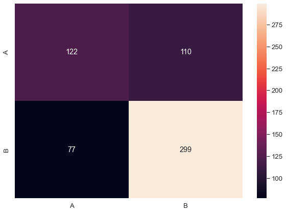

```python
from sklearn.metrics import confusion_matrix
from sklearn.metrics import cohen_kappa_score
import seaborn as sn

print(classification_report(y_test, predict_nb))
print(f"kappa: {cohen_kappa_score(y_test, predict_nb)}" )

a=confusion_matrix(y_test, predict_nb)
print("confusion matrix of RF :")
df_cm = pd.DataFrame(a, index = [i for i in "AB"],
                  columns = [i for i in "AB"])
plt.figure(figsize = (10,7))
sn.heatmap(df_cm, annot=True,fmt='g')
```

```python
area=pd.read_csv(r"S:\STUDY\Master SIGGT\PFE\DATA\Machine_learning_dataset\DATASET.csv",sep=',') #Data contanis our study area
area=area[area.columns[1:]]  #slicing
area


NB=nb.predict_proba(scaler.fit_transform(area))
a=NB[:,1:]
area["class"]=a
print(area["class"].describe())
print(area["class"].unique())
```

```
count     5.504770e+05
mean      6.207098e-01
std       3.166810e-01
min      5.855836e-175
25%       4.119659e-01
50%       7.057012e-01
75%       8.828757e-01
max       1.000000e+00
Name: class, dtype: float64
[3.32001225e-01 5.86623006e-01 9.39692694e-01 ... 1.02797434e-06
 1.50665798e-09 4.88659910e-07]
```

```
0.738799981658107
```

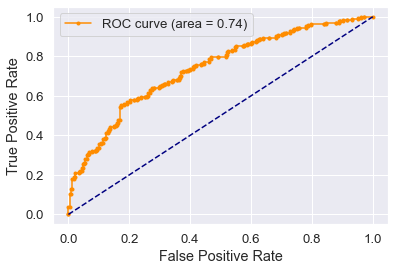

```python
from sklearn.metrics import roc_auc_score
from sklearn.metrics import roc_curve
from matplotlib import pyplot

predict_nb=nb.predict_proba(X_test)
predict_nb=predict_nb[:, 1]

lr_auc = roc_auc_score(y_test, predict_nb)
print(lr_auc)
lr_fpr, lr_tpr, _ = roc_curve(y_test, predict_nb)

# plot the roc curve for the model
pyplot.plot(lr_fpr, lr_tpr, marker='.', color='darkorange' , label='ROC curve (area = %0.2f)' % lr_auc)
plt.plot([0, 1], [0, 1], color='navy', linestyle='--')

# axis labels
pyplot.xlabel('False Positive Rate')
pyplot.ylabel('True Positive Rate')
# show the legend
pyplot.legend()
# show the plot
pyplot.show()
```

[figure not shown]

```python
import numpy as np
from sklearn.model_selection import train_test_split
from sklearn.metrics import accuracy_score
from sklearn.inspection import permutation_importance
import matplotlib.pyplot as plt

# Assume you have trained a RandomForestClassifier and assigned it to 'rfc'

# Calculate permutation importances
perm_importance = permutation_importance(nb, X_test, y_test, n_repeats=30, random_state=42)

# Get feature importances
feature_importances = perm_importance.importances_mean

# Extract feature names from the DataFrame
feature_names = features_b_.columns

# Optionally, plot the feature importances
plt.figure(figsize=(10, 6))
plt.bar(range(len(features_b_.columns)), feature_importances, tick_label=feature_names)
plt.xlabel('')
plt.ylabel('Permutation Importance')


plt.xticks(rotation=25, ha='right')  # Rotate x-axis labels 45 degrees

plt.title('SVM Permutation Importance of Features')

# Annotate the bars with the importance values
for i, v in enumerate(feature_importances):
    plt.text(i, v + 0.00, f'{v:.4f}', ha='center', va='bottom', fontsize=10)

plt.tight_layout()
plt.show()
```

```python
#Just to save our dataset
path_final=r'S:\STUDY\Master SIGGT\PFE\DATA\Machine_learning_dataset\NB.csv'
area.to_csv(path_final)
```

# ROC COMPARAISON

```
0.738799981658107
```

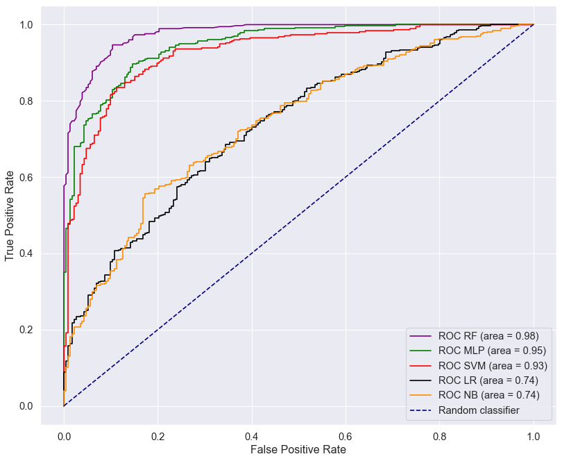

```python
from sklearn.metrics import roc_auc_score
from sklearn.metrics import roc_curve
from matplotlib import pyplot

predict_nb=nb.predict_proba(X_test)
predict_nb=predict_nb[:, 1]
from matplotlib.pyplot import figure

figure(figsize=(12, 10), dpi=80)
lr_auc = roc_auc_score(y_test, predict_nb)
lr_auc3 = roc_auc_score(y_test, predict_rfc)
lr_auc4 = roc_auc_score(y_test, predict_svm)
lr_auc1 = roc_auc_score(y_test, predict_LR)
lr_auc2 = roc_auc_score(y_test, predict_mlp)


print(lr_auc)
lr_fpr, lr_tpr, _ = roc_curve(y_test, predict_nb)
lr_fpr1, lr_tpr1, _ = roc_curve(y_test, predict_LR)
lr_fpr2, lr_tpr2, _ = roc_curve(y_test, predict_mlp)
lr_fpr3, lr_tpr3, _ = roc_curve(y_test, predict_rfc)
lr_fpr4, lr_tpr4, _ = roc_curve(y_test, predict_svm)


# plot the roc curve for the model
pyplot.plot(lr_fpr3, lr_tpr3,  color='purple' , label='ROC RF (area = %0.2f)' % lr_auc3)
pyplot.plot(lr_fpr2, lr_tpr2,  color='green' , label='ROC MLP (area = %0.2f)' % lr_auc2)

pyplot.plot(lr_fpr4, lr_tpr4,  color='red' , label='ROC SVM (area = %0.2f)' % lr_auc4)

pyplot.plot(lr_fpr1, lr_tpr1,  color='black' , label='ROC LR (area = %0.2f)' % lr_auc1)

pyplot.plot(lr_fpr, lr_tpr,  color='darkorange' , label='ROC NB (area = %0.2f)' % lr_auc)
plt.plot([0, 1], [0, 1], color='navy', linestyle='--' , label='Random classifier ')

# axis labels
pyplot.xlabel('False Positive Rate')
pyplot.ylabel('True Positive Rate')
# show the legend
pyplot.legend()
# show the plot
pyplot.show()
```

```python
from sklearn.metrics import roc_auc_score
from sklearn.metrics import roc_curve
from matplotlib import pyplot

predict_nb=nb.predict_proba(X_test)
predict_nb=predict_nb[:, 1]
from matplotlib.pyplot import figure

figure(figsize=(12, 10), dpi=80)
lr_auc = roc_auc_score(y_test, predict_nb)
lr_auc3 = roc_auc_score(y_test, predict_rfc)
lr_auc4 = roc_auc_score(y_test, predict_svm)
lr_auc1 = roc_auc_score(y_test, predict_LR)
lr_auc2 = roc_auc_score(y_test, predict_mlp)


print(lr_auc)
lr_fpr, lr_tpr, _ = roc_curve(y_test, predict_nb)
lr_fpr1, lr_tpr1, _ = roc_curve(y_test, predict_LR)
lr_fpr2, lr_tpr2, _ = roc_curve(y_test, predict_mlp)
lr_fpr3, lr_tpr3, _ = roc_curve(y_test, predict_rfc)
lr_fpr4, lr_tpr4, _ = roc_curve(y_test, predict_svm)


# plot the roc curve for the model
pyplot.plot(lr_fpr3, lr_tpr3,  color='purple' , label='ROC RF (area = %0.2f)' % lr_auc3)
pyplot.plot(lr_fpr2, lr_tpr2,  color='green' , label='ROC MLP (area = %0.2f)' % lr_auc2)

pyplot.plot(lr_fpr4, lr_tpr4,  color='red' , label='ROC SVM (area = %0.2f)' % lr_auc4)

pyplot.plot(lr_fpr1, lr_tpr1,  color='black' , label='ROC LR (area = %0.2f)' % lr_auc1)

pyplot.plot(lr_fpr, lr_tpr,  color='darkorange' , label='ROC NB (area = %0.2f)' % lr_auc)
plt.plot([0, 1], [0, 1], color='navy', linestyle='--' , label='Random classifier ')

# axis labels
pyplot.xlabel('False Positive Rate')
pyplot.ylabel('True Positive Rate')
# show the legend
pyplot.legend()
# show the plot
pyplot.show()
```

[output not shown]